# Задачи по Эконометрике: Бинарные переменные

Н.В. Артамонов (МГИМО МИД России)

# 1 Структурные сдвиги

## 1.1 Графики

Для набора данных `sleep75` рассмотрим линейную регрессию **sleep на totwrk** и подгоним отдельно для south=0, отдельно для south=1 и по полному датасету

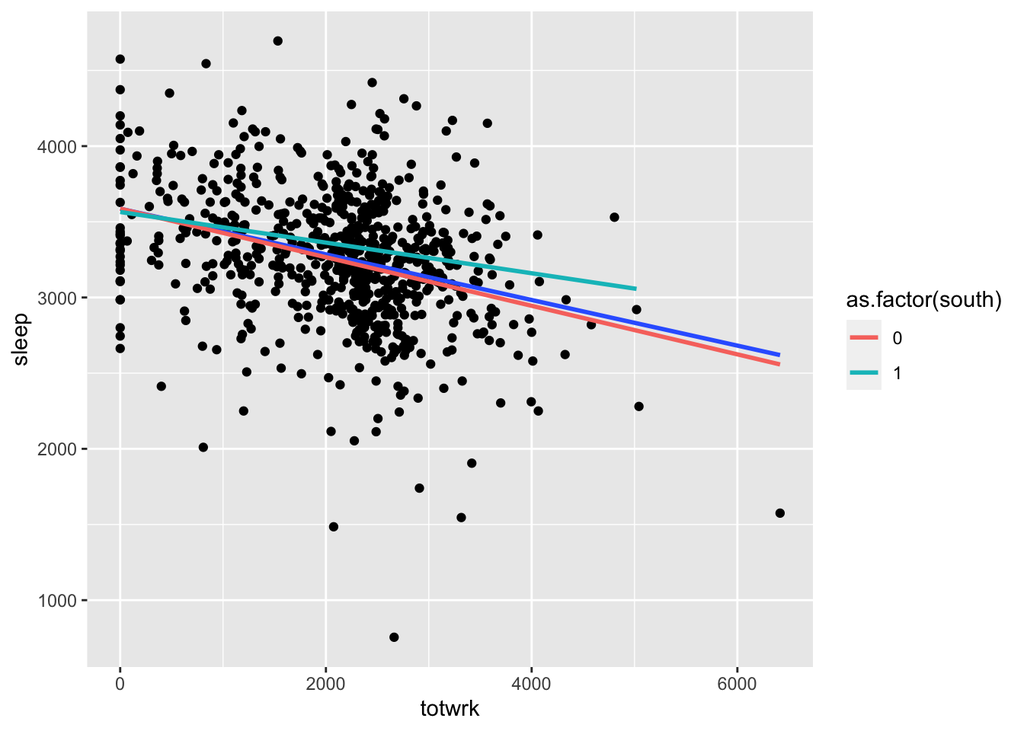

Для набора данных `sleep75` рассмотрим линейную регрессию **sleep на age, age^2** и подгоним отдельно для south=0, отдельно для south=1 и по полному датасету

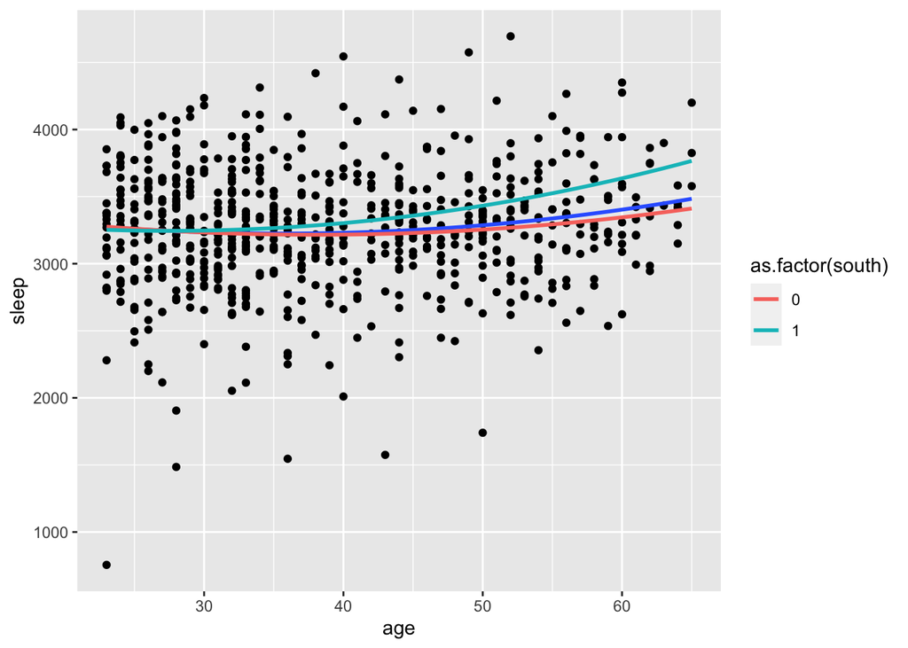

## 1.2 sleep equation #1

Для набора данных `sleep75` рассмотрим линейную регрессию **sleep на totwrk, age, smsa**: исходную и со структурными сдвигами относительно гендерной переменной.

Результаты оценивания

```
================================================
                        Зависимая переменная
                    ----------------------------
                               sleep
                         (1)            (2)
------------------------------------------------
totwrk                -0.150***      -0.143***
                       (0.017)        (0.026)

age                    2.997**         1.704
                       (1.393)        (2.085)

smsa                  -73.501**       -56.649
                       (32.219)      (48.902)

male                                  135.200
                                     (143.832)

totwrk:male                           -0.045
                                      (0.036)

age:male                               1.500
                                      (2.825)

smsa:male                             -34.735
                                     (64.938)

Constant             3498.670***    3486.973***
                       (69.133)      (92.418)

------------------------------------------------
Observations             706            706
R2                      0.115          0.126
Adjusted R2             0.112          0.117
Residual Std. Error    418.877        417.530
F Statistic           30.527***      14.387***
================================================
Note:                *p<0.1; **p<0.05; ***p<0.01
```

Уровень значимости 5%.

Для второй регрессии дайте интерпретацию выводам о значимости коэффициентов.

Тестируется значимость структурных сдвигов. Вычислите тестовую статистику, необходимое критическое значение. **Ответ округлите до 2-х десятичных знаков.**

Ответ

```
[1] "F.stat=2.2"
```

```
[1] "F.cr=2.38"
```

Значимы ли структурные сдивиги:

```
[1] "Незначимы"
```

Как можно объяснить значимость возраста в первой регресии и незначимость коэффициентов при возрастных регрессрах во второй?

## 1.3 sleep equation #2

Для набора данных `sleep75` рассмотрим линейную регрессию **sleep на totwrk, age, smsa**: исходную и со структурными сдвигами относительно географической переменной.

Результаты оценивания

```
================================================
                        Зависимая переменная
                    ----------------------------
                               sleep
                         (1)            (2)
------------------------------------------------
totwrk                -0.150***      -0.161***
                       (0.017)        (0.018)

age                    2.997**         1.485
                       (1.393)        (1.545)

smsa                  -73.501**      -61.554*
                       (32.219)      (34.856)

south                               -407.206**
                                     (189.627)

totwrk:south                           0.078
                                      (0.050)

age:south                             8.267**
                                      (3.495)

smsa:south                            49.429
                                     (107.111)

Constant             3498.670***    3557.513***
                       (69.133)      (75.504)

------------------------------------------------
Observations             706            706
R2                      0.115          0.131
Adjusted R2             0.112          0.122
Residual Std. Error    418.877        416.341
F Statistic           30.527***      15.039***
================================================
Note:                *p<0.1; **p<0.05; ***p<0.01
```

Уровень значимости 10%.

Для второй регрессии дайте интерпретацию выводам о значимости коэффициентов и значимым коэффицеинтам.

Тестируется значимость структурных сдвигов. Вычислите тестовую статистику, необходимое критическое значение. **Ответ округлите до 2-х десятичных знаков.**

Ответ

```
[1] "F.stat=3.21"
```

```
[1] "F.cr=1.95"
```

Значимы ли структурные сдивиги:

```
[1] "Значимы"
```

## 1.4 wage equation #1

Для набора данных `wage2` рассмотрим линейную регрессию **log(wage) на age, IQ, urban, married**: исходную и со структурными сдвигами относительно географической переменной.

Результаты оценивания

```
================================================
                        Зависимая переменная
                    ----------------------------
                             log(wage)
                         (1)            (2)
------------------------------------------------
age                    0.022***      0.024***
                       (0.004)        (0.005)

IQ                     0.009***      0.008***
                       (0.001)        (0.001)

urban                  0.186***      0.217***
                       (0.028)        (0.035)

married                0.198***      0.201***
                       (0.041)        (0.049)

south                                 -0.011
                                      (0.348)

age:south                             -0.007
                                      (0.009)

IQ:south                               0.002
                                      (0.002)

urban:south                          -0.114**
                                      (0.057)

married:south                         -0.003
                                      (0.087)

Constant               4.849***      4.914***
                       (0.163)        (0.204)

------------------------------------------------
Observations             935            935
R2                      0.188          0.205
Adjusted R2             0.184          0.197
Residual Std. Error     0.380          0.377
F Statistic           53.799***      26.481***
================================================
Note:                *p<0.1; **p<0.05; ***p<0.01
```

Уровень значимости 5%.

Для второй регрессии дайте интерпретацию выводам о значимости коэффициентов и значимым коэффицеинтам.

Тестируется значимость структурных сдвигов. Вычислите тестовую статистику, необходимое критическое значение. **Ответ округлите до 2-х десятичных знаков.**

Ответ

```
[1] "F.stat=3.96"
```

```
[1] "F.cr=2.22"
```

Значимы ли структурные сдивиги:

```
[1] "Значимы"
```

## 1.5 wage equation #2

Результаты оценивания

```
================================================
                        Зависимая переменная
                    ----------------------------
                             log(wage)
                         (1)            (2)
------------------------------------------------
age                    0.023***      0.024***
                       (0.004)        (0.007)

IQ                     0.008***      0.008***
                       (0.001)        (0.002)

south                 -0.113***       -0.014
                       (0.028)        (0.052)

urban                                  0.237
                                      (0.368)

age:urban                             -0.001
                                      (0.009)

IQ:urban                             -0.00001
                                      (0.002)

south:urban                           -0.117*
                                      (0.061)

Constant               5.214***      4.999***
                       (0.168)        (0.312)

------------------------------------------------
Observations             935            935
R2                      0.146          0.182
Adjusted R2             0.143          0.176
Residual Std. Error     0.390          0.382
F Statistic           52.872***      29.417***
================================================
Note:                *p<0.1; **p<0.05; ***p<0.01
```

Уровень значимости 10%.

Для второй регрессии дайте интерпретацию выводам о значимости коэффициентов и значимым коэффицеинтам.

Тестируется значимость структурных сдвигов. Вычислите тестовую статистику, необходимое критическое значение. **Ответ округлите до 2-х десятичных знаков.**

Ответ

```
[1] "F.stat=10.2"
```

```
[1] "F.cr=1.95"
```

Значимы ли структурные сдивиги:

```
[1] "Значимы"
```

# 2 Небинарные качественые признаки

## 2.1 diamond equation #1

Для набора данных `Diamond` рассмотрим несколько линейных регрессий. Результаты оценивания

```
=======================================================
                           Зависимая переменная
                    -----------------------------------
                                log(price)
                        (1)         (2)         (3)
-------------------------------------------------------
carat                5.667***    5.650***    5.404***
                      (0.135)     (0.198)     (0.121)

I(carat2)            -2.153***   -2.187***   -1.983***
                      (0.099)     (0.145)     (0.094)

colourE              -0.076**                -0.072**
                      (0.031)                 (0.032)

colourF              -0.152***               -0.143***
                      (0.029)                 (0.030)

colourG              -0.227***               -0.214***
                      (0.029)                 (0.030)

colourH              -0.313***               -0.305***
                      (0.030)                 (0.031)

colourI              -0.408***               -0.399***
                      (0.031)                 (0.032)

certificationHRD     0.042***      0.031
                      (0.015)     (0.022)

certificationIGI     0.085***     0.068**
                      (0.019)     (0.027)

Constant             5.866***    5.686***    5.975***
                      (0.049)     (0.063)     (0.042)

-------------------------------------------------------
Observations            308         308         308
R2                     0.984       0.965       0.983
Adjusted R2            0.983       0.964       0.982
Residual Std. Error    0.105       0.154       0.109
F Statistic         2031.977*** 2071.269*** 2414.298***
=======================================================
Note:                       *p<0.1; **p<0.05; ***p<0.01
```

Уровень значимости 1%.

Дайте интерпретацию (значимым) коэффициентам первой регресии.

Тестируется значимость влияния цвета, т.е. гипотеза $H_0:\beta_{colourE}=\beta_{colourF}=\beta_{colourG}=\beta_{colourH}=\beta_{colourI}=0$.

Вычислите тестовую статистику. **Ответ округлите до 2-х десятичных знаков.**

Ответ:

```
[1] 70.78
```

Вычислите критическое значение. **Ответ округлите до 2-х десятичных знаков.**

```
[1] 3.08
```

Вывод

```
[1] "Влияние значимо"
```

Тестируется значимость влияния сертификации, т.е. гипотеза $H_0:\beta_{certificationHRD}=\beta_{certificationIGI}=0$.

Вычислите тестовую статистику. **Ответ округлите до 2-х десятичных знаков.**

Ответ:

```
[1] 9.31
```

Вычислите критическое значение. **Ответ округлите до 2-х десятичных знаков.**

```
[1] 4.68
```

Вывод

```
[1] "Влияние значимо"
```

## 2.2 diamond equation #2

Для набора данных `diamonds` рассмотрим несколько линейных регрессий. Результаты оценивания

```
==========================================================
                             Зависимая переменная
                    --------------------------------------
                                  log(price)
                        (1)          (2)          (3)
----------------------------------------------------------
carat                 2.535***     2.365***     2.349***
                      (0.029)      (0.032)      (0.029)

I(carat2)            -0.646***    -0.644***    -0.610***
                      (0.006)      (0.007)      (0.006)

colorE               -0.030***                 -0.031***
                      (0.004)                   (0.004)

colorF               -0.039***                 -0.040***
                      (0.004)                   (0.004)

colorG               -0.071***                 -0.067***
                      (0.004)                   (0.004)

colorH               -0.210***                 -0.209***
                      (0.004)                   (0.004)

colorI               -0.308***                 -0.303***
                      (0.004)                   (0.004)

colorJ               -0.432***                 -0.433***
                      (0.005)                   (0.005)

cutGood               0.118***     0.116***
                      (0.007)      (0.007)

cutVery Good          0.177***     0.173***
                      (0.006)      (0.007)

cutPremium            0.161***     0.155***
                      (0.006)      (0.007)

cutIdeal              0.251***     0.245***
                      (0.006)      (0.007)

x                     0.339***     0.381***     0.376***
                      (0.008)      (0.009)      (0.008)

y                     0.015***     0.016***     0.027***
                      (0.004)      (0.004)      (0.004)

z                     0.063***     0.056***     0.045***
                      (0.006)      (0.007)      (0.006)

Constant              3.992***     3.795***     4.078***
                      (0.026)      (0.029)      (0.026)

----------------------------------------------------------
Observations           53940        53940        53940
R2                     0.949        0.936        0.946
Adjusted R2            0.949        0.936        0.946
Residual Std. Error    0.229        0.256        0.236
F Statistic         67068.470*** 87939.000*** 86084.180***
==========================================================
Note:                          *p<0.1; **p<0.05; ***p<0.01
```

Уровень значимости 5%.

Дайте интерпретацию (значимым) коэффициентам первой регресии.

Тестируется значимость влияния цвета, т.е. гипотеза $H_0:\beta_{colourE}=\beta_{colourF}=\beta_{colourG}=\beta_{colourH}=\beta_{colourI}=\beta_{colourJ}=0$.

Вычислите тестовую статистику. **Ответ округлите до 2-х десятичных знаков.**

Ответ:

```
[1] 2290.89
```

Вычислите критическое значение. **Ответ округлите до 2-х десятичных знаков.**

```
[1] 2.1
```

Вывод

```
[1] "Влияние значимо"
```

Тестируется значимость влияния качества огранки, т.е. гипотеза $H_0:\beta_{сutGOOD}=\beta_{cutVery Good}=\beta_{cutPremium}=\beta_{cutIdeal}=0$.

Вычислите тестовую статистику. **Ответ округлите до 2-х десятичных знаков.**

Ответ:

```
[1] 793
```

Вычислите критическое значение. **Ответ округлите до 2-х десятичных знаков.**

```
[1] 2.37
```

Вывод

```
[1] "Влияние значимо"
```